# SKOC62: Forskningsmetoder i strategisk kommunikation VT24

Quantitative methods workshops 1 — 4

Author

nils.holmberg@isk.lu.se

## 0.1 Introduction

[interactive chart not shown]

- SPSS download student version: [link](https://www.lu.se/studera/livet-som-student/it-tjanster-support-och-driftinfo/programvara)
- SPSS canvas data file: [link](https://canvas.education.lu.se/courses/21228/files/3453815/download?download_frd=1)
- SPSS tutorial in english: [link](https://www.lse.ac.uk/Methodology/Software-tutorials/SPSS-tutorials)
- SPSS tutorial in swedish: [link](https://www.graduateschool.sam.lu.se/current-students/student-links-and-resources/methods-resources-thesis-writing/how-use-spss)
- Observe that instructions become less and less detailed as you work your way through the tasks.
- Open SPSS. Log into the course website at Canvas. Download the file Communicative Organizations Database.
- **SUPER IMPORTANT!! Save your data file and all changes so you can use it for the following workshops! Also save your output files or copy paste relevant parts to another document if you want to remember what you did in the previous workshop!**

# 1 Workshop: Descriptive statistics

## 1.1 Finding your way around SPSS

1. Open the dataset. Go to variable view in the data window. Take a look at the variable `Gender` (nr 2). What are the possible values of this variable?
2. Inspect the variable `femcomm_mgmt` (nr 32). What does this variable measure? What are the possible values?

## 1.2 First steps: visualizing the data

1. Inspect the variable Gender (nr 2) and create a pie chart. Choose: `Analyze -> Descriptive statistics -> Frequencies` in the drop-down menu. Find Gender in the list of variables. You can either double-click it or mark it and click the arrow. Choose: `Charts -> Pie chart -> Continue -> OK`. Observe the results in the Output window. What is the distribution of gender in the sample? Is a pie chart a good way of visualizing this variable? Note: 999 indicates that the respondent did not answer the question; System-missing indicates the question was not asked at all.

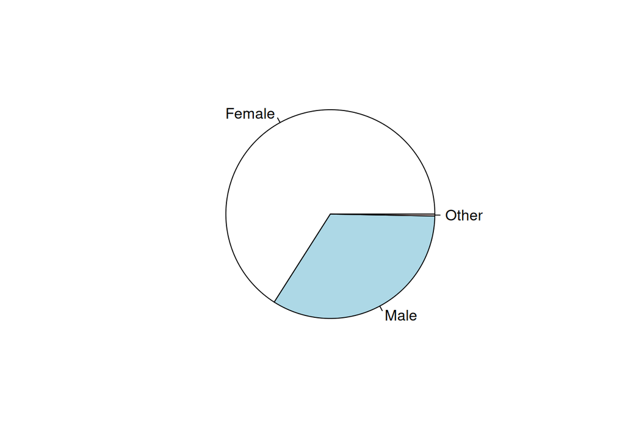

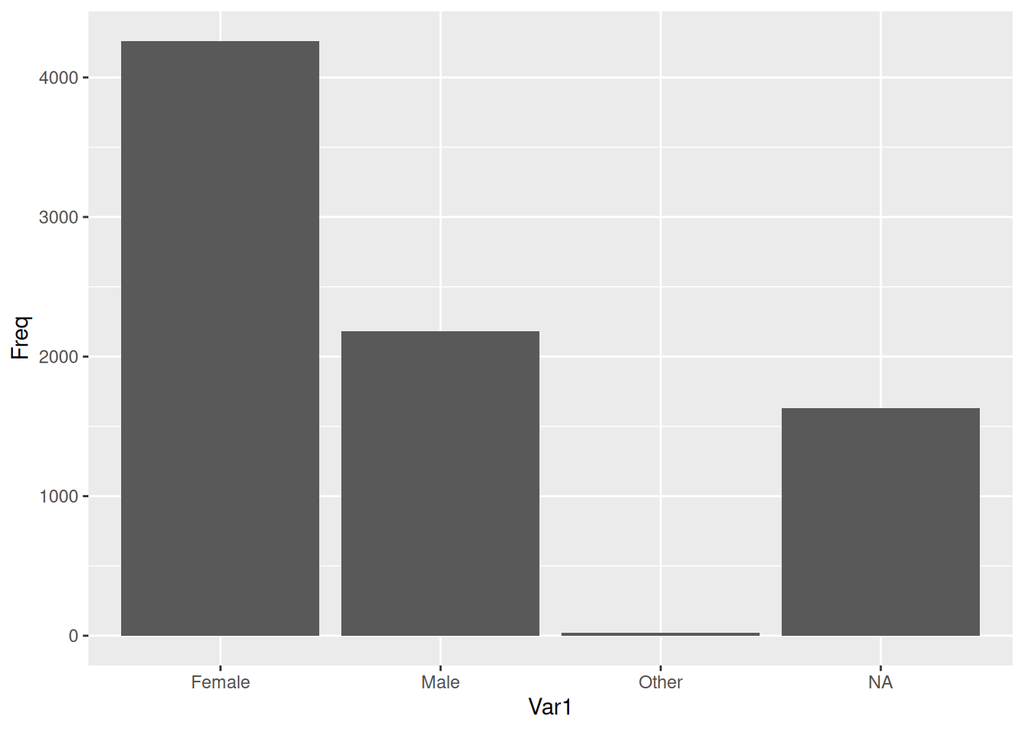

2. Repeat step a using the variable femcomm_mgmt (nr 32), but create a bar chart instead of a pie chart. Choose: `Analyze -> Descriptive statistics -> Frequencies -> Charts -> Bar chart`. Observe: by right-clicking the list of variables in the pop-up window, you can choose whether you want the variables displayed by label or name. How did the respondents of the survey answer this question? How many respondents answered this question?
3. Inspect the variable `Role` (nr 5). Create a bar chart. Observer the numbers of communicators in the survey and compare the number to the number of valid responses for femcomm_mgmt (nr 32).

## 1.3 Finding incorrect data

1. Look at the distribution of `Age` (nr 3) and report the mean and the median for the variable. Produce a histogram. Choose: `Frequencies -> Statistics -> Mean and Median -> Continue` and then `Charts -> Histogram -> Continue -> OK`. How is age measured in this variable (= what do the scores represent)? Do some scores seem to be incorrectly reported? What is the highest age? What is the lowest age? What is the median and mean age?
2. Explore the Age variable further by choosing `Analyze -> Descriptive statistics -> Explore` and enter Age into the Dependent variable field. Click on: `Statistics -> Outliers -> Click OK`. Inspect the table Extreme values. Do any of the scores in the table strike you as odd? Go to the box plot (the image shown at the bottom). Note the case numbers shown.
3. Go to data view in the data window. Look up case nr 3611. Choose either of these two options: 1) Change the score to the score you believe is the correct one. 2) Change the score to the median score of the variable.
4. Repeat step c. with other cases where you think the age score might have been entered incorrectly. **Remember to save your changes!**

## 1.4 Cross tables

1. Create a cross table with the variables Gender and femcomm_mgmt. Choose: `Analyze -> Descriptive statistics -> Cross tabs`. Enter the variable Gender into Column(s) and femcomm_mgmt into Row(s). Click: `Cells -> Percentages -> Columns -> Continue -> OK`. Do men and women seem to differ over whether female communicators need to work harder than men in order to secure good relations to management?
2. Repeat 1.4.a with the variables `Role` (nr 5) and `extcomm` (nr 30). Are there any differences in how different groups view the contributions of communicators to effective external communication?

## 1.5 Compare means

1. Do employees of different age perceive gossiping at the workplace differently? Let’s find out! Compare the mean age for different responses to the statement “Gossiping is a problem within the organization” (`org_gossip`, nr. 17). Choose: `Analyze -> Compare means -> Means` from the drop-down menu. Insert Age in the box titled Dependent list and org_gossip in the box titled Independent list. Click OK. (Note: this does not mean that we actually believe that Age is the dependent variable here, since your opinions on gossiping can have no effect on your age. This is only a practical way for us to find out age differences.)

**THAT’S IT FOR TODAY! REMEMBER TO SAVE YOUR DATA AND OUTPUT FILES (THOSE ARE TWO DIFFERENT OPERATIONS)!**

# 2 Workshop: Data transformation

## 2.1 Recoding variables

1. Create a cross table with `Role` (nr 5) as the column variable, and `org_gossip` (nr 17) as the row variable. Do managers have more of a problem with gossip than other groups?
2. Recode org_gossip into a variable with only three values: disagree, neither, and agree. First, note the different possible values for the variable. Choose `Transform -> Recode into different variables` from the drop-down menu. Insert the variable into the box titled `Input variable -> Output variable`. In the fields Name and Label, write `org_gossip_cat` (in both fields). Click Change. Click Old and New Values. In Old Value, write 1 and in New Value, write 1. Click Add. Repeat with the other values (2=1, 3=2, 4=3, 5=3). Click Continue and OK. You have now created a new variable `org_gossip_cat` with 3 categories instead of 5.
3. Go to variable view. Look up the new variable (it’s at the bottom of the list). Mark the empty field in the column Values. Click the three dots. In the pop-up window, write in the new values: In Value, write 1 and in Label Disagree. Repeat for values 2 (Neither) and 3 (Agree). Click OK.
4. Create a frequency table for the new variable AND for the old variable. **Do the numbers match? This is a way of knowing whether you recoded correctly.**
5. Create a cross table with Role as the column variable and the new variable `org_gossip_cat` as the row variable. Do the differences appear more clearly now?

## 2.2 Computing variables

1. The variable for `Age` is measured in birth years. We will now recode it into measuring age in years of age. Your current age is 2024 – your birth year. We shall perform this calculation for all respondents. The survey was conducted in late 2015 – early 2016 (see Falkheimer et al, 2017). We will use 2016 for all respondents.
2. Choose `Transform -> Compute variable`. In the field Target Variable, write the name of your new variable. Remember to name it in a way that is understandable to you! Click Type and Label and choose Use expression as label. Write “2016 – Age” in the field Numeric Expression. Click OK.

```
[1] 1967
```

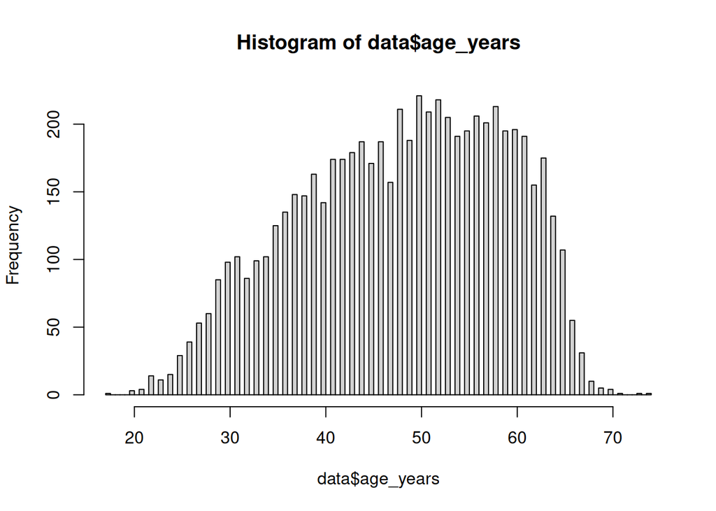

```
   Min. 1st Qu.  Median    Mean 3rd Qu.    Max.    NA's
   17.0    40.0    49.0    48.1    57.0    74.0    1684
```

3. Inspect the new variable. What is the mean and median age? Does it correspond with the original variable?

## 2.3 Creating an index

1. Consider the variables 31-35 (`femcomm_performance, femcomm_mgmt, femcomm_opportunity, femcomm_support, and femcomm_barriers`). Run frequency tables for all of them. What do they measure? Do they seem to have something in common? (Hint: they do.)
2. Look at the individual values of the variables. Do they all have the same number of values? **Are they coded in the same direction?**
3. Run a reliability test to see whether the variables are suitable for combining into an index. Choose `Analyze -> Scale -> Reliability analysis` from the drop-down menu. Transfer the variables into the field Items. Click Statistics. Choose Scale if item deleted, Continue and OK.
4. Inspect the table Reliability Statistics. Crombach’s Alpha should have a value above 0,7. In the table Item – Total statistics you can see how the Crombach’s Alpha varies when one item is excluded.
5. Create a summative index variable by choosing `Transform -> Compute Variable` from the drop-down menu. Name the index variable `index_femcomm`, genderdiffindex, or something else that allows you to remember what it represents. Simply sum the variables in the field Numerical Expression by double-clicking the first variable, select +, double-click the second variable, and so on. Click OK.
6. Run a frequency table of the new variable and select Mean, Median, Std. deviation, S.E. Mean, and skewness and kurtosis under Statistics. Also produce a Histogram (under Charts) and choose Show normal curve on histogram.
7. **What is the minimum and maximum score?** What is the mean and the median? Does the variable seem to be approximately normally distributed?

## 2.4 A first attempt of hypothesis testing

1. Are female or male communicators more likely to score high on the index we created above? Let’s find out! Choose Compare Means and enter Gender as the independent variable and our new index as the dependent variable. What is the mean score for men and women, respectively?
2. Is this a statistically significant difference? Let’s find out! Choose `Analyze -> Compare means -> Independent-Samples t-test` from the drop-down menu. Insert the index variable into the field Test Variable(s). Insert the Gender variable into the field Grouping Variable. Click Define Groups. Write 1 in the field Group 1 and 2 in the field Group 2. This means that we will compare the mean score on the index for the females (1) and the males (2). A t-test is a test for statistical significance which we will talk more about later.
3. Inspect the tables. The first table, `Group Statistics`, tell you what we already know: that women score higher than men on the index. The next table reports the result of two tests: `Levene’s test` for equality of variances and the `t-test` for equality of means. If Levene’s test is significant (under Sig. check if the value is below 0.05), we assume equal variances. As the test is significant, look at the row for equal variances. What is the value reported under Sig.? If it is below 0.05, the test is significant. If the test is significant, it means that the probability for the difference in mean scores between women and men being an effect of random variation is below 5%.
4. Congratulations, you have distinguished the signal from the noise and found a non-trivial statistically significant relationship between two variables!

**THAT’S IT FOR TODAY! REMEMBER TO SAVE YOUR DATA AND OUTPUT FILES (THOSE ARE TWO DIFFERENT OPERATIONS)!**

# 3 Workshop: Bivariate analysis

## 3.1 Univariate analysis

1. Create a new summative `index_infoaccess` using the variables 6-11: `info_work, info_org, info_vision, info_change, info_intracomm and info_mgmttrust`. Note central tendency, dispersion and normal distribution.

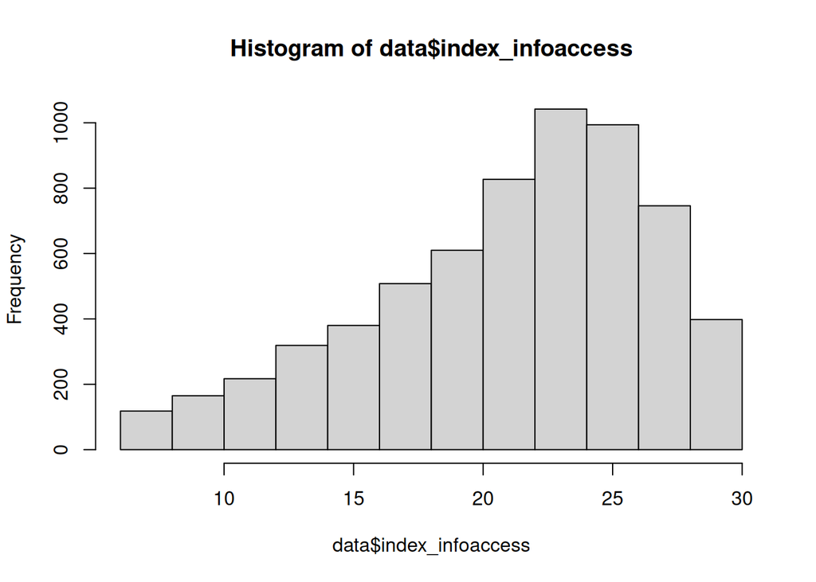

```r
# create index variable
data$index_infoaccess = rowSums(as_tibble(lapply(data[,6:11], as.numeric)))
# visualize distribution
hist(data$index_infoaccess)
```

```r
# get descriptive stats
summary(data$index_infoaccess)
```

```
   Min. 1st Qu.  Median    Mean 3rd Qu.    Max.    NA's
   6.00   18.00   23.00   21.49   26.00   30.00    1767
```

2. Take a look at the following variables: `Age` in years (see previous workshop), `Gender`, `Role`, and `Org_type`. Note the dispersion, central tendency and normal distribution of the variables as applicable. Are the variables quantitative (ratio/interval) or qualitative (nominal/ordinal)?
3. How can we think about the possible effects that the variables in 1b can have on the index in 1a? What does the index measure?

## 3.2 Bivariate analysis

1. Perform bivariate analyses for each of the variables in 1b and the `index_infoaccess`. Use compare means to compare with qualitative variables; use correlate to compare with quantitative variables. (NB: For tests of statistical significance when comparing means, please follow instructions given during the workshop (ie independent samples t-test and one-way ANOVA).)
2. Now perform bivariate analyses for each of the variables in 1b pairwise (i.e. compare them with each other, using cross tables, compare means, or correlation as applicable). Note any significant relationships.

## 3.3 Creating dummy variables

1. Recode `Gender` to a variable with only two categories, Female=1 and Male=0. Compare it with the original variable to make sure you coded correctly. Name it `dummy_gender`.

```
Female   Male  Other   <NA>
  4262   2179     19   1631
```

```
 Factor w/ 3 levels "Female","Male",..: 1 2 1 1 1 1 2 2 2 1 ...
```

```
[1] "Female" "Male"   "Other"
```

```
  _male _female    <NA>
   2179    4262    1650
```

2. Recode Role into three separate dummy variables as follows: Create three new variables named `dummy_manager`, `dummy_communicator`, and `dummy_coworker`. dummy_manager should have the value 1 for manager and 0 for all other values in the old variable. dummy_communicator should have the vale 1 for communicator and 0 for all other values in the old variable. dummy_coworker should have the value 1 for coworkers and 0 for all other values in the old variable. Compare the dummy variables with the original variable Role to make sure you coded correctly. Note that you will use these variables during the next workshop!

```
                    Manager                    Coworker
                       1520                        6068
Communicator or equivalent                         <NA>
                        499                           4
```

```
[1] "Manager"                     "Coworker"
[3] "Communicator or equivalent "
```

**THAT’S IT FOR TODAY! REMEMBER TO SAVE YOUR DATA AND OUTPUT FILES (THOSE ARE TWO DIFFERENT OPERATIONS)!**

# 4 Workshop: Multivariate analysis

## 4.1 Multiple regression analysis

1. Create a model using multiple regression analysis `Analyze -> Regression -> Linear`.
2. Under Dependent, enter your dependent variable (`index_infoaccess`, Workshop #3 task 1a). Under Independent(s), enter your independent variables: `Age` in years (see Workshop #2 task 2), `dummy_gender`, `Org_type`, `dummy_manager` and `dummy_communicator` (Workshop #3 task 3). Click OK.
3. Choose `Method, Enter`.
4. Under Statistics, choose `Estimates, Confidence intervals, Model fit, Descriptives`. Under Residuals: `Casewise diagnostics, Outliers`.
5. Under Options, choose `Exclude cases pairwise`.
6. Under Plots, put `*ZRESID` in Y box and `*ZPRED` in X box; tick the box for Normal probability plot. Click OK to run regression analysis.

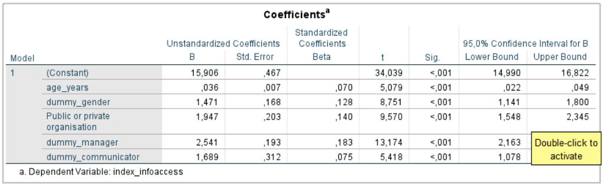

model

7. Correlations: check for multicollinearity (no bivariate above 0.7)
8. Normal PP plot: check for normality (should be straight diagonal)
9. Scatterplot: check for homoscedasticity, (should have rectangular shape with most scores in the centre)
10. ANOVA: F-test tells you whether model is useful (should be significant).
11. Model summary: R squared tells you how much of variance in the dependent variable can be regressed to the independent variables.
12. Coefficients: What variables have significant coefficients? Under Standardized coefficients, note positive/negative relationship and the relative size of the coefficients.
13. How do you interpret the model?
14. Try to take out one or two independent variables. How does it affect the R square?

**THAT’S IT FOR TODAY! REMEMBER TO SAVE YOUR DATA AND OUTPUT FILES (THOSE ARE TWO DIFFERENT OPERATIONS)!**